# ggplot exercises

Jon Chernus

# Setup

First we simulate data for 1000 individuals:

- genotypes coded 0, 1, 2 for 10 SNPs
- `phenotype` (height in cm., continuous)
- `weight` (in kg., continuous)
- `sex` (binary, `"M"` or `"F"`)

```r
# Load packages
library("knitr")
library("tidyverse")
# Parameters
set.seed(2073)
n_individuals <- 1000
n_snps <- 10

# Randomly generate data
#   Genotypes for 10 SNPs (coded 0, 1, 2)
#   Phenotype
#   Sex
#   Weight
#   Also add an ID
# Check data
snp_data <- as.data.frame(matrix(sample(0:2, n_individuals * n_snps, replace = TRUE), nrow = n_individuals))
colnames(snp_data) <- paste("SNP", 1:n_snps, sep = "_")
snp_data$phenotype <- rnorm(n_individuals, mean = 160, sd = 10)
snp_data$sex <- sample(c("F","M"), n_individuals, replace = TRUE)
snp_data$weight <- rnorm(n_individuals, mean = 70, sd = 15)
snp_data$ID <- paste0("subject",1:n_individuals)
```

Here is what the dataset looks like:

```r
# Show data
kable(head(snp_data))
```

| SNP_1 | SNP_2 | SNP_3 | SNP_4 | SNP_5 | SNP_6 | SNP_7 | SNP_8 | SNP_9 | SNP_10 | phenotype | sex | weight | ID |
| --- | --- | --- | --- | --- | --- | --- | --- | --- | --- | --- | --- | --- | --- |
| 0 | 2 | 1 | 1 | 2 | 1 | 0 | 1 | 0 | 0 | 159.1894 | M | 85.77384 | subject1 |
| 0 | 1 | 2 | 0 | 2 | 1 | 1 | 2 | 2 | 1 | 173.9825 | M | 61.41873 | subject2 |
| 0 | 0 | 0 | 1 | 0 | 1 | 2 | 0 | 0 | 1 | 170.4168 | M | 73.38361 | subject3 |
| 2 | 0 | 2 | 0 | 0 | 2 | 0 | 1 | 0 | 0 | 153.6477 | F | 70.49108 | subject4 |
| 2 | 2 | 1 | 0 | 2 | 1 | 2 | 0 | 2 | 1 | 158.3303 | M | 48.78646 | subject5 |
| 1 | 2 | 1 | 2 | 0 | 2 | 0 | 0 | 0 | 0 | 153.3224 | F | 86.49227 | subject6 |

# Exercises

Try experimenting with plotting parameters to see if you can improve on the defaults (including axis labels and titles).

## 1. Plot the overall distribution of the `phenotype`

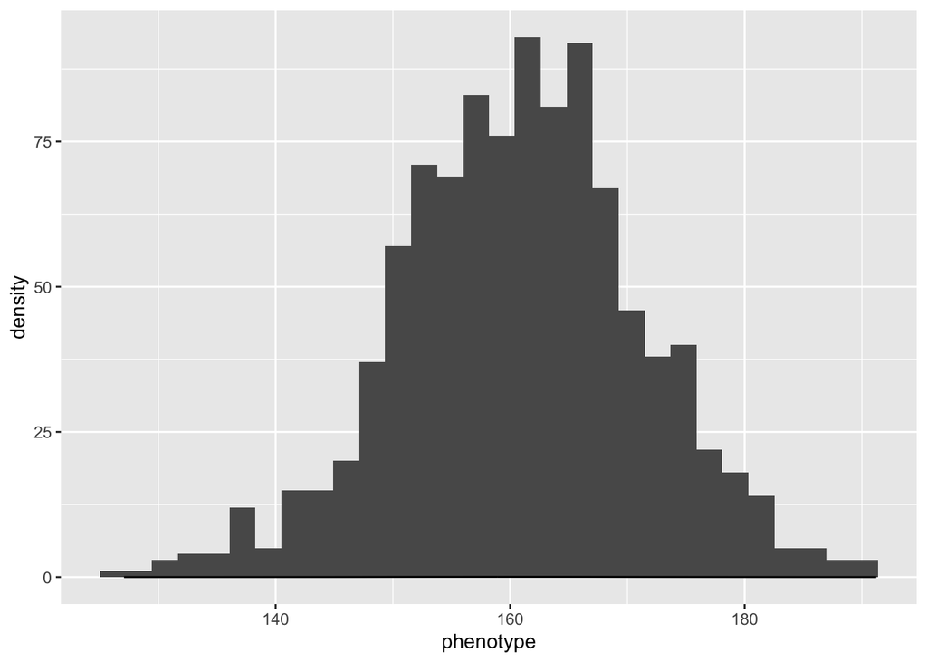

```r
# Your code here
snp_data %>% ggplot(aes(x=phenotype)) +
  geom_histogram() +
  geom_density()
```

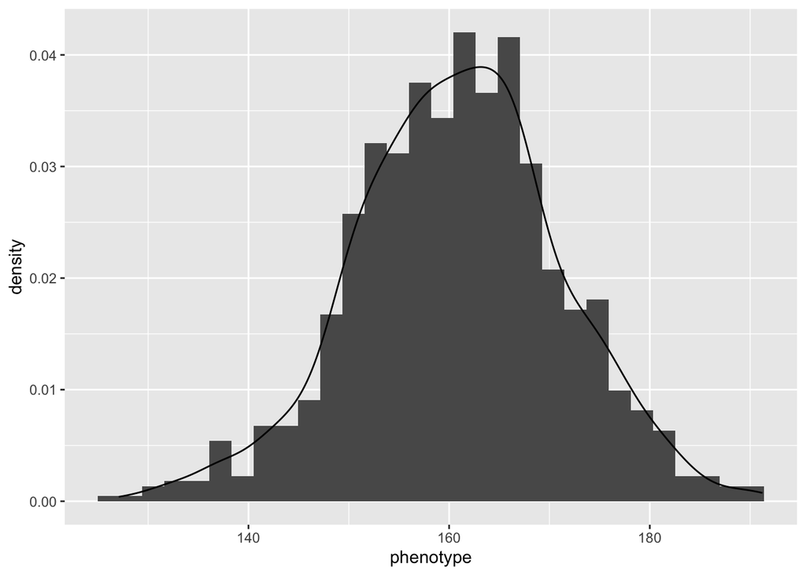

```r
snp_data %>% ggplot(aes(x=phenotype)) +
  geom_histogram(aes(y=..density..)) +
  geom_density()
```

## 2. Plot the distribution of the `phenotype` by `sex`

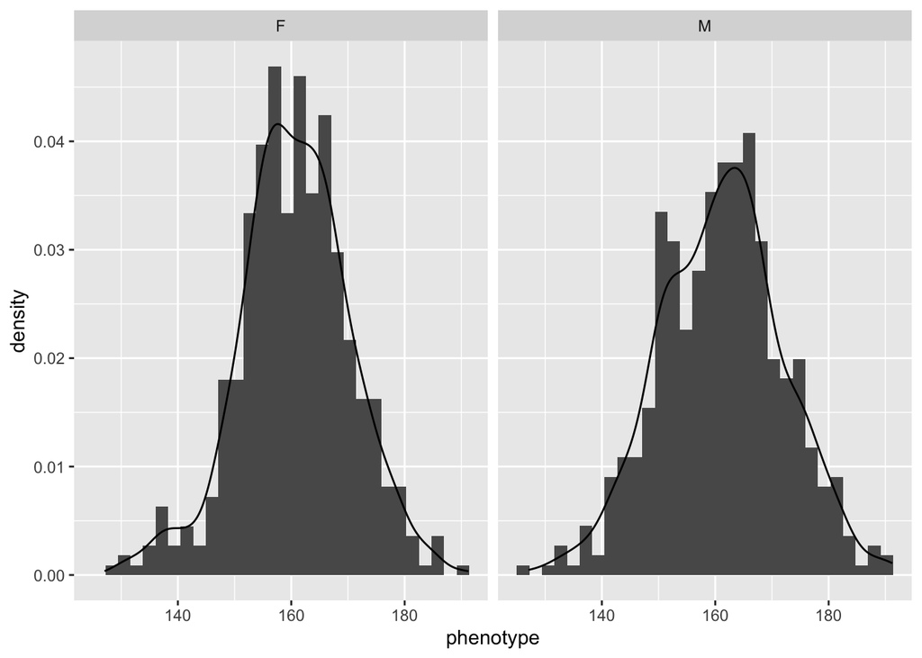

```r
# Your code here
snp_data %>% ggplot(aes(x=phenotype)) +
  geom_histogram(aes(y=..density..)) +
  geom_density() +
  facet_wrap(~sex)
```

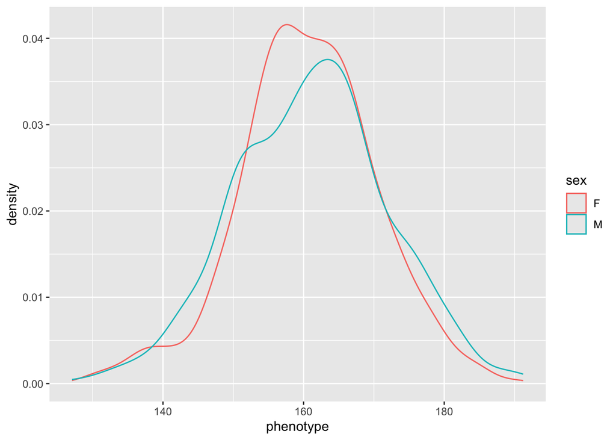

```r
snp_data %>% ggplot(aes(x=phenotype)) +
  #geom_histogram(aes(y=..density..)) +
  geom_density(aes(color=sex))
```

## 3. Make a barplot of the “haplotype” counts for `SNP_1` and `SNP_2`

This two-way table shows how the genotypes of SNP_1 and SNP_2 are related.

```r
# Show bins
kable(table(snp_data$SNP_1, snp_data$SNP_2))
```

|  | 0 | 1 | 2 |
| --- | --- | --- | --- |
| 0 | 108 | 109 | 108 |
| 1 | 107 | 115 | 111 |
| 2 | 113 | 107 | 122 |

Let’s make a single variable called `haplo12` that says summarizes genotype for `SNP_1` and `SNP_2`.

```r
# Make a binning variable
snp_data$haplo12 <- paste(snp_data$SNP_1, snp_data$SNP_2, sep="_")
kable(table(snp_data$haplo12))
```

| Var1 | Freq |
| --- | --- |
| 0_0 | 108 |
| 0_1 | 109 |
| 0_2 | 108 |
| 1_0 | 107 |
| 1_1 | 115 |
| 1_2 | 111 |
| 2_0 | 113 |
| 2_1 | 107 |
| 2_2 | 122 |

Now make a plot showing the counts in all 9 categories.

```r
# Your code here
```

## 4. Make a scatterplot with trendline of `phenotype` vs. `weight`, stratifying by `SNP_1` genotype

```r
# Your code here
```

## 5. Make a scatterplot of `phenotype` vs. `weight`, faceting by `SNP_1` genotype and stratified by `sex`

```r
# Your code here
```

```r
# Your code here
```

## 7. Make an interesting plot of your choice

```r
# Your code here
```

# Solutions

These are just suggestions - there are other ways to do these exercises.

## 1.

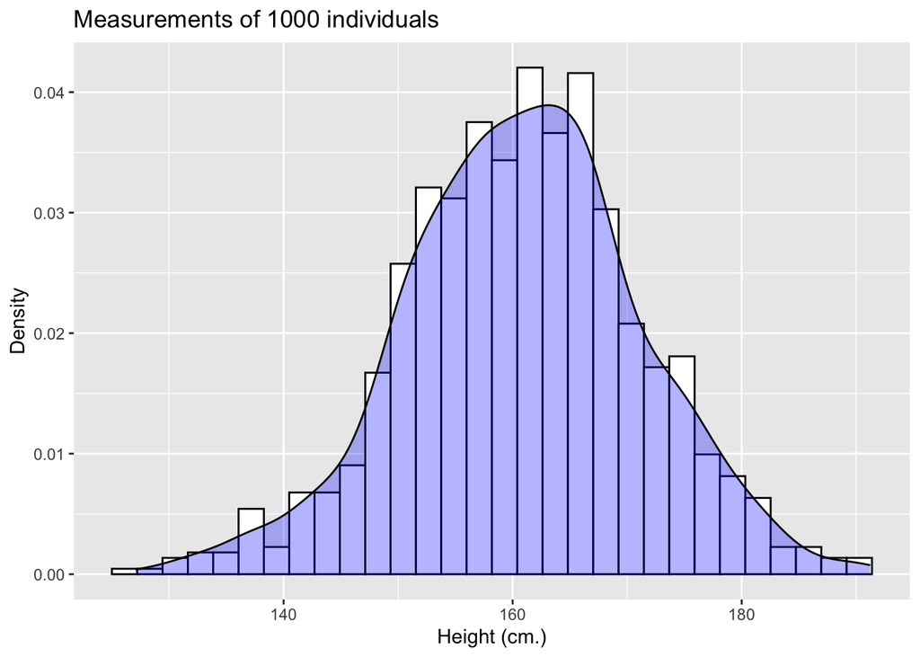

```r
snp_data %>% ggplot() +
  geom_histogram(aes(x=phenotype, y=..density..), color=1, fill="white") +
  geom_density(aes(x=phenotype), fill="blue", alpha=0.3) +
  xlab("Height (cm.)") + ylab("Density") + ggtitle("Measurements of 1000 individuals")
```

## 2.

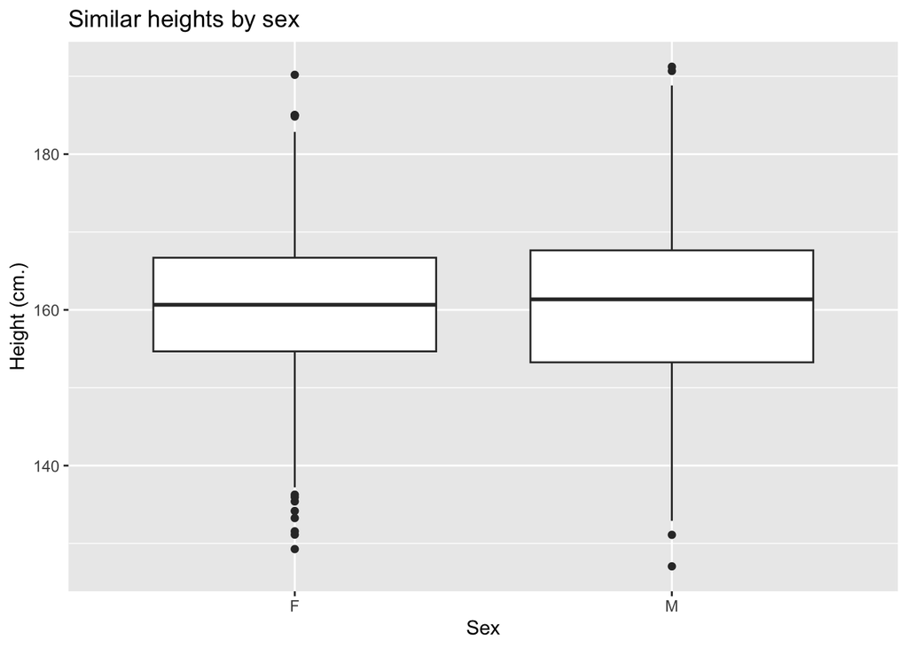

```r
snp_data %>% ggplot() +
  geom_boxplot(aes(x=sex, y=phenotype)) +
  xlab("Sex") + ylab("Height (cm.)") + ggtitle("Similar heights by sex")
```

## 3.

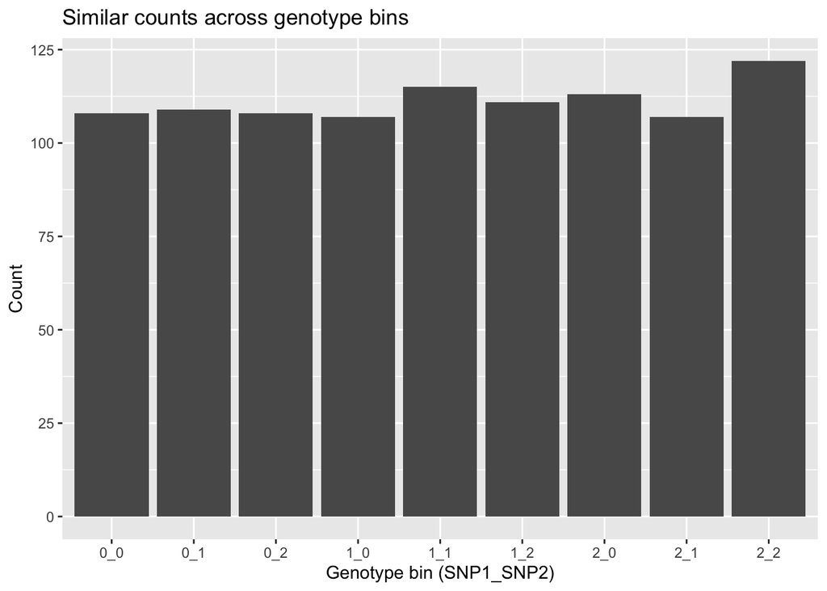

```r
snp_data %>% ggplot() +
  geom_bar(aes(x=haplo12)) +
  xlab("Genotype bin (SNP1_SNP2)") + ylab("Count") +
  ggtitle("Similar counts across genotype bins")
```

## 4.

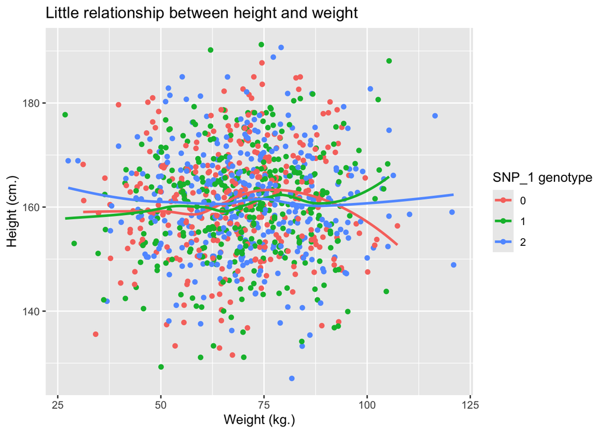

```r
snp_data %>% ggplot() +
  geom_point(aes(x=weight, y=phenotype, color=factor(SNP_1))) +
  geom_smooth(aes(x=weight, y=phenotype, color=factor(SNP_1)), se = FALSE) +
  xlab("Weight (kg.)") + ylab("Height (cm.)") +
  ggtitle("Little relationship between height and weight") +
  guides(color=guide_legend(title="SNP_1 genotype"))
```

## 5.

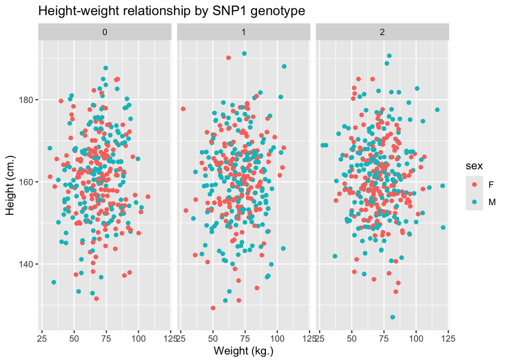

```r
snp_data %>% ggplot() +
  geom_point(aes(x=weight, y=phenotype, color=sex)) +
  facet_grid(~SNP_1) +
  xlab("Weight (kg.)") + ylab("Height (cm.)") +
  ggtitle("Height-weight relationship by SNP1 genotype")
```

## 6.

I’ve also added a `haplo12`-specific trend-line to each.

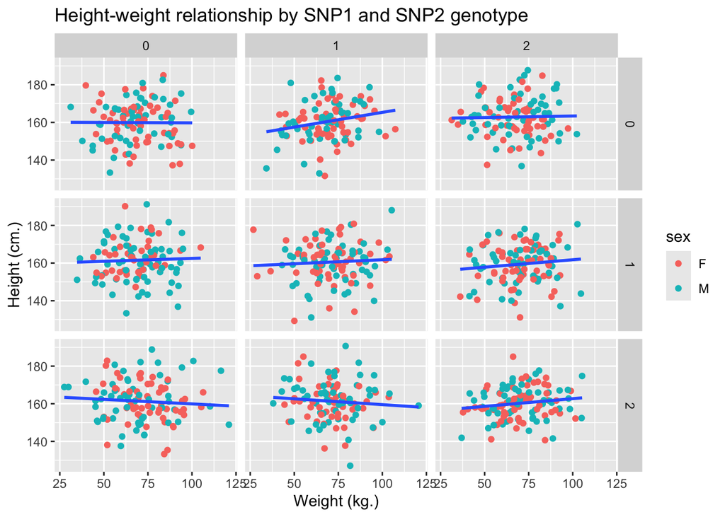

```r
snp_data %>% ggplot() +
  geom_point(aes(x=weight, y=phenotype, color=sex)) +
  geom_smooth(aes(x=weight, y=phenotype, group=haplo12), se=FALSE, method="lm") +
  facet_grid(SNP_1 ~ SNP_2) +
  xlab("Weight (kg.)") + ylab("Height (cm.)") +
  ggtitle("Height-weight relationship by SNP1 and SNP2 genotype")
```

## 7.

You get to answer this one.

```r
# Your code here
```